# Visualizing United States Census Data

5/21/2019

## Agenda

- History of the U.S. Census
- Getting started with Tidycensus
- Analysis with examples from Delaware

## US Census Timeline

- 1790: 6 question survey / U.S. pop just under 4 million
- 1810: Census adds data collection on U.S. manufacturers
- 1849: Congress establishes Census Board
- 1890: Herman Hollerith’s tabulation machine used in data collection
- 1900: Census becomes a permant agency and inter-decennial data collection begins
- 1920: For first time, majority of U.S. pop lives in urban areas / U.S. pop over 106 million
- 1940: First use of statistical sampling
- 1960: DIME (Dual Independent Map Encoding)
- 1970: All data products available on magnetic computer tape
- 1980: Mailout / Mailin Surveys
- 2000: U.S. Census asks ten questions
- 2010: American Community Survey 5-year estimates released

## Tidycensus Overview

- Developed by Kyle Walker
- [Check out the package on Github!](https://github.com/walkerke/tidycensus)
- Tidycensus is an API wrapper that allows R users to ingest decennial surveys and the American Community Survey (ACS) estimates
- Census data back to the 1990 decennial survey is available
- The defaul in the 5-year ACS estimate from 2013-2017

## Getting an API key

- https://api.census.gov/data/key_signup.html
- You’ll then recieve an e-mail from the census with your API key

```r
api_key <- "xxxxxxxx"
census_api_key(api_key, install = TRUE)
Sys.getenv("CENSUS_API_KEY")
```

## Variable Search

```r
library(tidycensus)
v17 <- load_variables(2017, "acs5", cache = TRUE)
v17
```

```
## # A tibble: 25,070 x 3
##    name      label                         concept
##    <chr>     <chr>                         <chr>
##  1 B00001_0… Estimate!!Total               UNWEIGHTED SAMPLE COUNT OF THE …
##  2 B00002_0… Estimate!!Total               UNWEIGHTED SAMPLE HOUSING UNITS
##  3 B01001_0… Estimate!!Total               SEX BY AGE
##  4 B01001_0… Estimate!!Total!!Male         SEX BY AGE
##  5 B01001_0… Estimate!!Total!!Male!!Under… SEX BY AGE
##  6 B01001_0… Estimate!!Total!!Male!!5 to … SEX BY AGE
##  7 B01001_0… Estimate!!Total!!Male!!10 to… SEX BY AGE
##  8 B01001_0… Estimate!!Total!!Male!!15 to… SEX BY AGE
##  9 B01001_0… Estimate!!Total!!Male!!18 an… SEX BY AGE
## 10 B01001_0… Estimate!!Total!!Male!!20 ye… SEX BY AGE
## # … with 25,060 more rows
```

## Load Var Function

```r
vt <- get_acs(geography = "county",
              variables = c(medincome = "B19013_001"),
              state = "VT")
```

## What is Tidy Data

All of the tidyverse packages operate easily when you have data in this structure!

Three interrelated rules:

1. Each variable must have its own column.
2. Each observation must have its own row.
3. Each value must have its own cell.

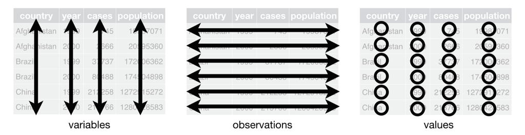

*https://r4ds.had.co.nz/tidy-data.html#fig:tidy-structure*

## Why should I care?

R is a vectorized language, meaning you can do operations like:

```r
v1 <- c(1, 2, 3, 4)
v2 <- c(5, 6, 7, 8)
v2-v1
```

```
## [1] 4 4 4 4
```

instead of writing a *for loop* to subtract the individual elements

The packages inside the tidyverse, e.g `dplyr`, let you do data cleaning and manipulation operations easily when data is in tidy format.

Using these packages can help - write faster and more ‘readable’ code

## Brief Concepts - Some commands you’ll see

- `%>%` “pipe” operator for chaining
- `filter` to subset a dataframe
- `group_by` and then `summarise`
- `facet` to create small multiples plots
- `left_join` to join datasets

## Let’s Start the Analysis!

## Setup

- Install [R](https://www.r-project.org) and [RStudio](https://www.rstudio.com/products/rstudio/download/)
- Download the [Repository](https://github.com/eturkel/Wilmington-Census)

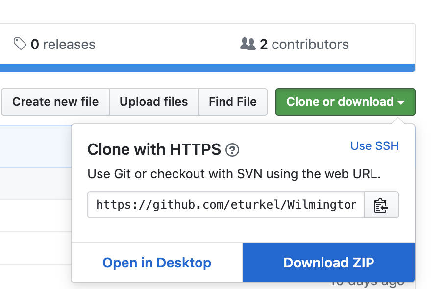

**OR**

- Use this RStudio Cloud workspace: https://rstudio.cloud/project/352564

## Install Packages (If Local Setup)

```r
install.packages("sf")
install.packages("tidycensus")
install.packages("dplyr")
install.packages("ggplot2")
install.packages("tidyr")
install.packages("purrr")
install.packages("lwgeom")
```

## Load Libraries

```r
library(dplyr)
library(ggplot2)
library(tidyr)
library(sf)
library(tidycensus)
library(tigris)
library(purrr)
```

## Your Choices!

Get an API Key from http://api.census.gov/data/key_signup.html

```r
census_api_key("<YOUR API KEY>")
demo_variables <- # define the variables you want to analyze here
de_census_data <- get_acs(geography = "tract",
                          state = "DE",
                          variables = demo_variables,
                          geometry = TRUE,
                          cb = TRUE)
```

OR

Load de_census_data.RData

```r
load("data/de_census_data.RData")
```

## Look at the data

```r
de_census_data
```

```
## Simple feature collection with 2616 features and 5 fields (with 12 geometries empty)
## geometry type:  MULTIPOLYGON
## dimension:      XY
## bbox:           xmin: -75.78866 ymin: 38.45101 xmax: -75.04894 ymax: 39.83901
## epsg (SRID):    4269
## proj4string:    +proj=longlat +ellps=GRS80 +towgs84=0,0,0,0,0,0,0 +no_defs
## First 10 features:
##          GEOID                                    NAME
## 1  10001040100 Census Tract 401, Kent County, Delaware
## 2  10001040100 Census Tract 401, Kent County, Delaware
## 3  10001040100 Census Tract 401, Kent County, Delaware
## 4  10001040100 Census Tract 401, Kent County, Delaware
## 5  10001040100 Census Tract 401, Kent County, Delaware
## 6  10001040100 Census Tract 401, Kent County, Delaware
## 7  10001040100 Census Tract 401, Kent County, Delaware
```

[output cut: 25 more lines]

## Onto Plotting!

We use the ggplot2 package for **layering** plot info. `geom_sf` is used to map the varied shapes (polygons, lines)

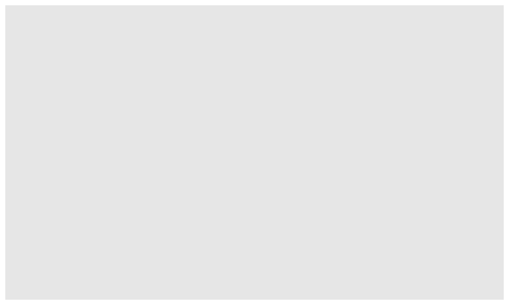

```r
ggplot(de_census_data, aes(fill = estimate))
```

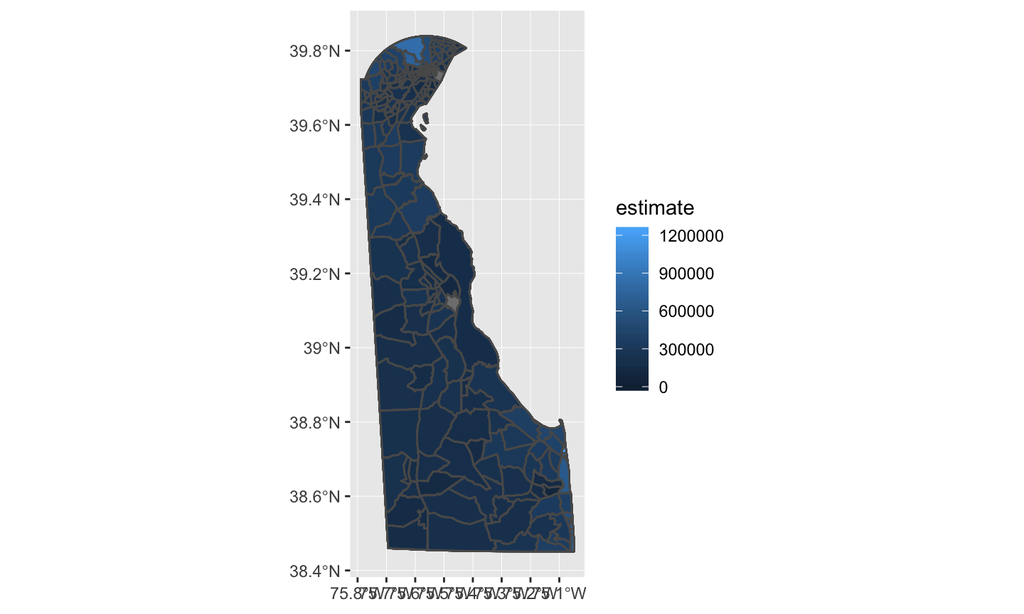

```r
ggplot(de_census_data, aes(fill = estimate)) +
  geom_sf()
```

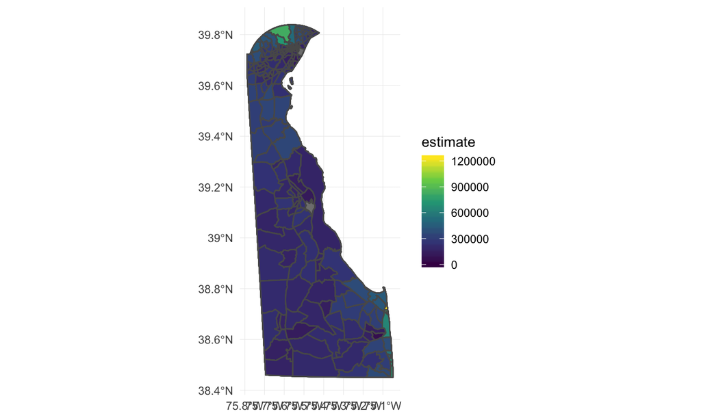

```r
ggplot(de_census_data, aes(fill = estimate)) +
  geom_sf() +
  scale_fill_viridis_c() +
  theme_minimal()
```

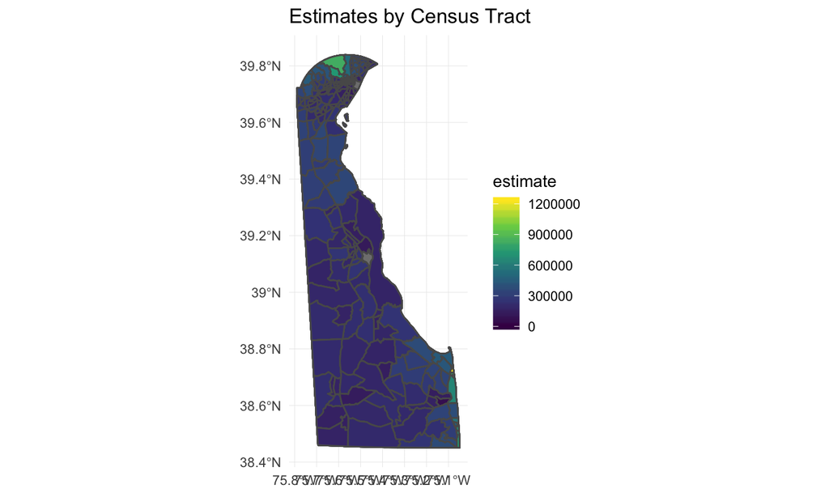

```r
ggplot(de_census_data, aes(fill = estimate)) +
  geom_sf() +
  scale_fill_viridis_c() +
  theme_minimal() +
  labs(title = "Estimates by Census Tract")
```

## Some Cleaning using `%>%`

```r
de_census_data_clean <- de_census_data %>%
    separate(col = NAME, into = c("Census_Tract", "County", "State"),
             sep = ",") %>%
    separate(col = Census_Tract, into = c("Census", "Tract", "Census_Tract_Number"),
             sep = " ")
```

## Using the grammar

Let’s look at the above code step by step

```r
de_census_data %>% # take the data, and then
    separate(col = NAME, into = c("Census_Tract", "County", "State"),
             sep = ",") # separate by ','
```

```
## Simple feature collection with 2616 features and 7 fields (with 12 geometries empty)
## geometry type:  MULTIPOLYGON
## dimension:      XY
## bbox:           xmin: -75.78866 ymin: 38.45101 xmax: -75.04894 ymax: 39.83901
## epsg (SRID):    4269
## proj4string:    +proj=longlat +ellps=GRS80 +towgs84=0,0,0,0,0,0,0 +no_defs
## First 10 features:
##          GEOID     Census_Tract       County     State
## 1  10001040100 Census Tract 401  Kent County  Delaware
## 2  10001040100 Census Tract 401  Kent County  Delaware
## 3  10001040100 Census Tract 401  Kent County  Delaware
## 4  10001040100 Census Tract 401  Kent County  Delaware
## 5  10001040100 Census Tract 401  Kent County  Delaware
## 6  10001040100 Census Tract 401  Kent County  Delaware
## 7  10001040100 Census Tract 401  Kent County  Delaware
```

[output cut: 25 more lines]

```r
de_census_data %>% # take the data, and then
    separate(col = NAME, into = c("Census_Tract", "County", "State"),
             sep = ",") %>% # separate, and then
    separate(col = Census_Tract, into = c(NA, NA, "Census_Tract_Number"),
             sep = " ") # separate out Number
```

```
## Simple feature collection with 2616 features and 7 fields (with 12 geometries empty)
## geometry type:  MULTIPOLYGON
## dimension:      XY
## bbox:           xmin: -75.78866 ymin: 38.45101 xmax: -75.04894 ymax: 39.83901
## epsg (SRID):    4269
## proj4string:    +proj=longlat +ellps=GRS80 +towgs84=0,0,0,0,0,0,0 +no_defs
## First 10 features:
##          GEOID Census_Tract_Number       County     State
## 1  10001040100                 401  Kent County  Delaware
## 2  10001040100                 401  Kent County  Delaware
## 3  10001040100                 401  Kent County  Delaware
## 4  10001040100                 401  Kent County  Delaware
## 5  10001040100                 401  Kent County  Delaware
## 6  10001040100                 401  Kent County  Delaware
## 7  10001040100                 401  Kent County  Delaware
```

[output cut: 25 more lines]

```r
# this result is assigned to de_census_data_clean using the assignment operator '<-'
```

## Pick one Variable to view Estimates

```r
# Let's look at the number of foreignborn in each Tract
de_census_fb <- de_census_data_clean %>%
  filter(variable %in% c("foreignborn"))
```

```r
ggplot(de_census_fb, aes(fill = estimate)) +
  geom_sf() +
  scale_fill_viridis_c() +
  coord_sf(crs = 26916, datum = NA) +
  labs(title = "Foreign-Born Estimates by DE Census Tract",
       caption = "Data: 2013-2017 5-year ACS",
       fill = "ACS estimate")
```

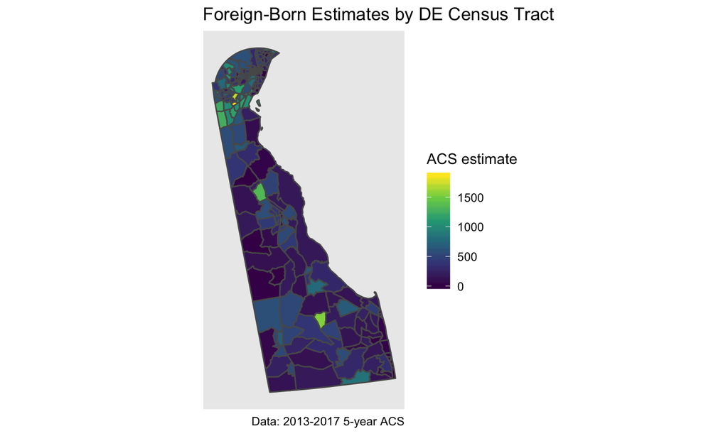

```r
ggplot(de_census_fb, aes(fill = estimate)) +
  geom_sf() +
  scale_fill_viridis_c() +
  coord_sf(crs = 26916, datum = NA) +
  labs(title = "Foreign-Born Estimates by DE Census Tract",
       caption = "Data: 2013-2017 5-year ACS",
       fill = "ACS estimate")
```

## Subset only Wilmington using Tract

```r
# Wilmington Tracts
wilm_census_data <- de_census_data_clean %>%
  filter(Census_Tract_Number %in% c(2, 3, 4, 5, 6.01, 6.02, 9, 11, 12,
                                    13, 14, 15, 16, 19.02, 21, 22, 23,
                                    24, 25, 26, 27, 28, 29, 30.02))
```

## Let’s Plot EVERYTHING!

```r
# Plot all our data
ggplot(wilm_census_data, aes(fill = estimate)) +
  geom_sf() +
  scale_fill_viridis_c() +
  coord_sf(crs = 26916, datum = NA) +
  labs(title = "Estimates by Census Tract",
       subtitle = "Wilmington, DE",
       caption = "Data: 2013-2017 5-year ACS
       \nData acquired with the R tidycensus package.",
       fill = "ACS estimate") +
  facet_wrap(~variable)
```

## What’s the problem?

[figure not shown]

## Plotting some comparable Variables

```r
## filter race
wilm_census_race <- wilm_census_data %>%
  filter(variable %in% c("hispanic", "black", "asian", "white"))
```

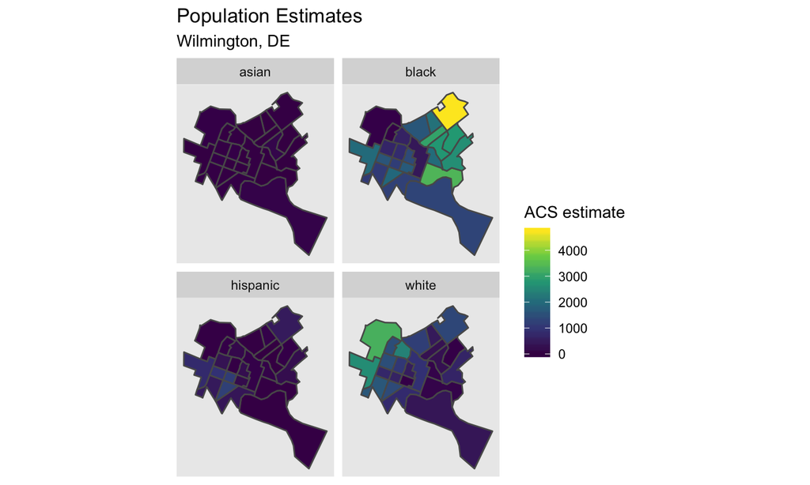

```r
ggplot(wilm_census_race, aes(fill = estimate)) +
  geom_sf() +
  scale_fill_viridis_c() +
  coord_sf(crs = 26916, datum = NA) +
  labs(title = "Population Estimates",
       subtitle = "Wilmington, DE",
       fill = "ACS estimate") +
  facet_wrap(~variable)
```

## Comparing a Better Way

‘Small multiples plots’ are useful to compare between variables. But we need to make sure we compare the right proportions so as to not let people take away a wrong insight.

Let’s do some data aggregation and data joins to find the percentages within each tract.

Highlight sections and run using `cmd`+ `return` to see the separate steps.

```r
# get the total population by summing up the different race estimates
wilm_tract_pop <- wilm_census_race %>%
  group_by(Census_Tract_Number) %>%
  summarise(Population_Estimate = sum(estimate))

st_geometry(wilm_tract_pop) <- NULL # remove geometry

wilm_tract_percpop <- wilm_census_race %>%
  left_join(wilm_tract_pop, by = "Census_Tract_Number") %>%
  mutate(Percentage = estimate/Population_Estimate)
```

Note: tidycensus allows you to get the summary value through the API as well!

## Plot Percentage Population

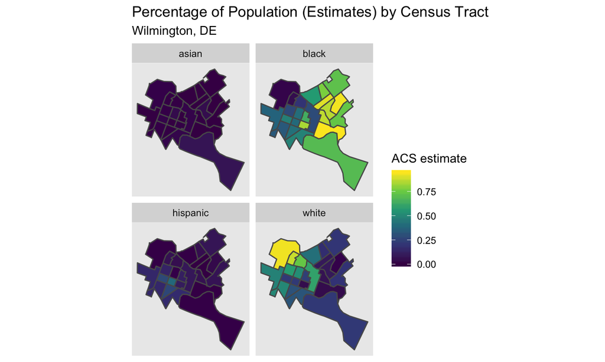

```r
ggplot(wilm_tract_percpop, aes(fill = Percentage)) +
  geom_sf() +
  scale_fill_viridis_c() +
  coord_sf(crs = 26916, datum = NA) +
  labs(title = "Percentage of Population (Estimates) by Census Tract",
       subtitle = "Wilmington, DE",
       fill = "ACS estimate") +
  facet_wrap(~variable)
```

## Your Turn

You can create a Wilmington Education variable by filtering `c("high_school_diplomas", "bachelor_degrees", "masters_degrees")` variables and recreating the previous visualizations for these variables.

## Answer

```r
wilm_census_edu <- wilm_census_data %>%
  filter(variable %in% c("high_school_diplomas", "bachelor_degrees", "masters_degrees"))

ggplot(wilm_census_edu, aes(fill = estimate)) +
  geom_sf() +
  scale_fill_viridis_c() +
  coord_sf(crs = 26916, datum = NA) +
  labs(title = "Education Estimates",
       subtitle = "Wilmington, DE",
       fill = "ACS estimate") +
  facet_wrap(~variable)
```

```r
# As a percentage of education data available (this isn't perfect)
# get the total population by summing up the different race estimates
wilm_tract_totedu <- wilm_census_edu %>%
  group_by(Census_Tract_Number) %>%
  summarise(Education_Estimate = sum(estimate))

st_geometry(wilm_tract_totedu) <- NULL # remove geometry

wilm_tract_percedu <- wilm_tract_totedu %>%
  left_join(wilm_census_edu, by = "Census_Tract_Number") %>%
  mutate(Percentage = estimate/Education_Estimate)

# Plot
ggplot(wilm_tract_percedu, aes(fill = Percentage)) +
  geom_sf() +
  scale_fill_viridis_c() +
  coord_sf(crs = 26916, datum = NA) +
  labs(title = "Percentage of Education Estimates by Census Tract",
       subtitle = "Wilmington, DE",
       fill = "ACS estimate") +
  facet_wrap(~variable)
```

## Dot Density Plots

Choropleth maps have a tendency of being misunderstood due to the *area* covered by a color. We can plot dots in order to avoid the issue of misrepresentation of sparsely populated areas and give an idea of density.

Hold tight as this will have some heavy lifting with functions from dplyr and purrr!

```r
wm_dots <- map(c("white", "black", "asian", "hispanic"), function(group) {
    wilm_census_data %>%
        filter(variable == group) %>%
        st_sample(., size = .$estimate / 10, exact = FALSE) %>%
        st_sf() %>%
        mutate(group = group)
}) %>%
    reduce(rbind) %>%
    group_by(group) %>%
    summarize()
```

[output not shown]

[output cut: 130 more lines]

[output not shown]

`map` Applys a function to each element of a vector, in our case the vector is the race values. i.e, for each race we subset the wilmington data, and create dots representing the population in each tract.

```r
wilm_census_data %>%
        filter(variable == group) %>%
        st_sample(., size = .$estimate / 10, exact = FALSE) %>%
        st_sf() %>%
        mutate(group = group)
```

- st_sample() generates a sample of random dots each one representing 10 people.
- st_sf() converts the POINT geometry set back to simple features dataframe.

## Plotting it all together

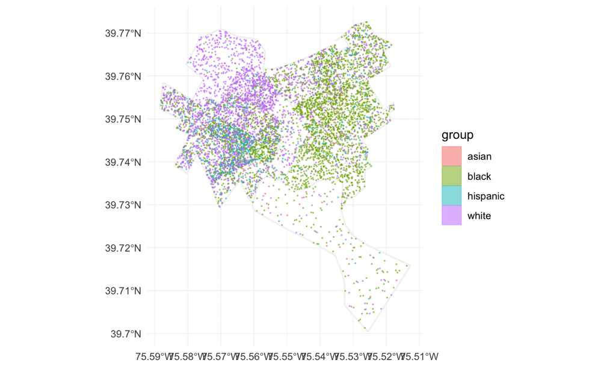

```r
ggplot() +
    geom_sf(data = wilm_census_data, color = "grey95", fill = "white") +
    geom_sf(data = wm_dots, aes(color = group, fill = group),
            size = 0.1, alpha = 0.5) +
    theme_minimal()
```

## Looking back

Data being tidy allowed us to immediately use commands like:

- facet
- group_by

Remember ACS are estimates so we should consider the MOE or Margin of Error variable.

## Next steps

- Try using another layer with alpha to show the MOE [*](https://www.cdc.gov/dhdsp/maps/gisx/training/module4/files/4_mapping_uncertainty_module-508.pdf)
- Integrate this data with statistics from the Uniform Crime Reporting database
- Ask interesting questions and use tidy functions to get quick results

## Extra Questions

- What are the high median rent areas?
- Does the median house value correlate with houses earning above 200k
- Among high median house value ones what is the percentage of owner/renter
- More Education levels more Median income
- Bachelors earning more (baby boomer identification)
- Where are the Vacant houses and the median income in these areas